# Week9 Tutorial - SVM

17/3/2021

```r
# Import libraries
library(DataExplorer)
library(missForest)
library(tidyverse)
library(reshape2)
library(ggplot2)
library(caTools)
library(caret)
library(e1071)
library(psych)
library(ROCR)
library(mice)
library(VIM)
```

## 1. Dataset Description

### 1.1 General Information

#### Dataset: https://www.kaggle.com/fernandolima23/classification-in-asteroseismology

#### Reference: https://www.kaggle.com/jetakow/logistic-regression-test-auc-0-991-acc-0-95

This dataset contains different measures of stars. Our goal is to classify the stars into two categories (RGB-HeB classification) based on these measures.

- Feature number: 4
- Instance number: 1001

### 1.2 Independent Variables

1. Dnu F8.5 (uHz) (Continuous variable): ‘Mean large frequency separation of modes with the same degree and consecutive order’.
2. Numax F9.5 (uHz) (Continuous variable): ‘Frequency of maximum oscillation power’.
3. Epsilon F7.3 (Continuous variable): ‘Location of the mode’.

### 1.3 Dependent Variables

1. Pop (Categorical variable): HeB (1), RGB (0).
- RGB (Red Giant Branch): the portion of the giant branch before helium ignition occurs in the course of stellar evolution.
- HeB (Helium Burning): the fusion of helium in the contracted core of a red giant star at extremely high temperatures, hotter than those reached in the Sun.

## 2. Why we choose this dataset?

1. SVM is not suitable for long-term time series forecasting. Nowadays, when talking about sequential data (CV, NLP), all we need are Transformers. Therefore, we choose a binary classification task in this project.
2. SVM performs better on a small dataset since it requires massive computation.
3. Also, we need to select appropriate hyper-parameters and kernels for SVM models.

```r
# Load data
df <- read.csv('classification_in_asteroseismology.csv', header = T)
```

## 3. Dataset Overview

```r
summary(df)
```

```
      POP              Dnu             numax           epsilon
 Min.   :0.0000   Min.   : 2.500   Min.   : 17.98   Min.   :0.0050
 1st Qu.:0.0000   1st Qu.: 4.073   1st Qu.: 32.92   1st Qu.:0.2200
 Median :1.0000   Median : 4.309   Median : 38.29   Median :0.8150
 Mean   :0.7123   Mean   : 5.775   Mean   : 58.44   Mean   :0.6108
 3rd Qu.:1.0000   3rd Qu.: 6.580   3rd Qu.: 70.14   3rd Qu.:0.8900
 Max.   :1.0000   Max.   :17.699   Max.   :239.65   Max.   :1.0000
```

```r
# Dataset info
str(df)
```

```
'data.frame':   1001 obs. of  4 variables:
 $ POP    : int  1 0 1 1 0 1 1 0 1 1 ...
 $ Dnu    : num  4.45 6.94 2.65 4.24 10.45 ...
 $ numax  : num  43.1 74.1 21.6 32.1 120.4 ...
 $ epsilon: num  0.985 0.15 0.855 0.84 0.275 0.945 0.985 0.215 0.885 0.855 ...
```

## 4. Data Imputation

```r
# Prior to treating missing values any blanks in the data set must be converted to NA.
df <- mutate_all(df, na_if, "")
```

### 4.1 Plot Missing Values

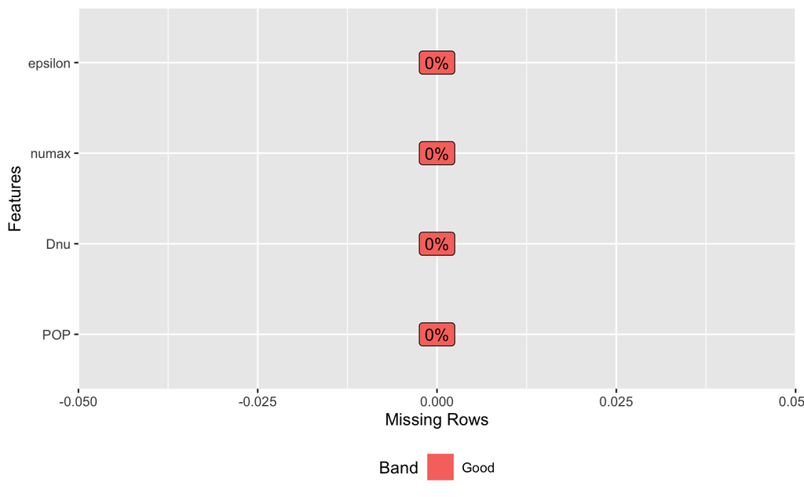

```r
# Viewing and counting missing data using DataExplorer package.
plot_missing(df)
```

Good News, there is no missing value now.

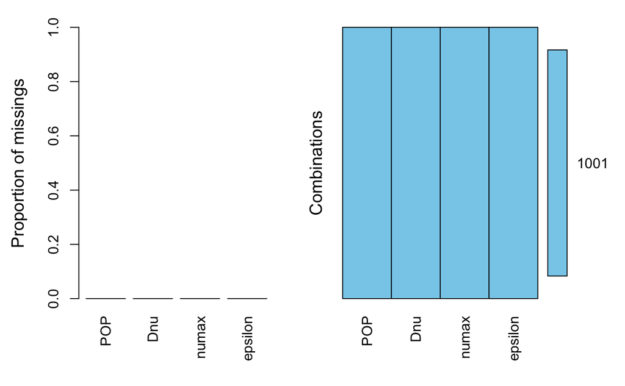

```r
# Using VIM library
vim_plot <- aggr(df, numbers=TRUE, prop = c(TRUE, FALSE))
```

As we can see, we have 1001 records in total, and no missing value in this data set.

This function plots and calculates the amount of missing values in each variable and in certain combinations. On the right-hand chart, we can see the missing values’ distribution in a combination. Notice that left-hand chart uses proportions as Y-axis, while the right one uses real number because we set prop = c(TRUE, FALSE).

[output not shown]

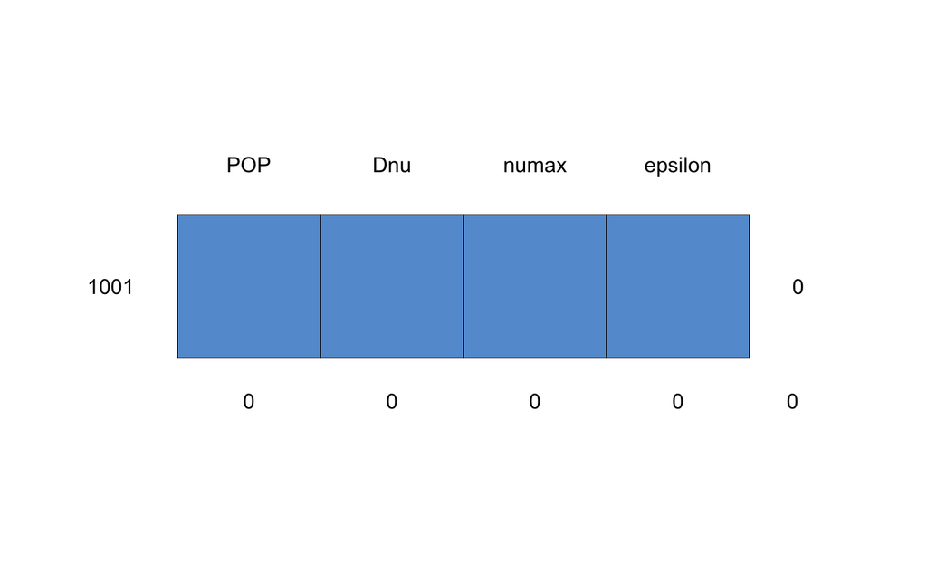

```r
# Using mice library
md.pattern(df)
```

This chart demonstrates the distribution of missing values. The values on the left side represent different groups of the data set. The values on the right side represent the total number of variables that contain missing value. The top line are names of different variables. The bottom line represents the number of missing values of each variable.

```r
# Overview of new data set
sum(is.na(df))
```

```
[1] 0
```

```r
head(df, 10)
```

|  | POP | Dnu | numax | epsilon |
| --- | --- | --- | --- | --- |
| 1 | 1 | 4.44780 | 43.06289 | 0.985 |
| 2 | 0 | 6.94399 | 74.07646 | 0.150 |
| 3 | 1 | 2.64571 | 21.57891 | 0.855 |
| 4 | 1 | 4.24168 | 32.13189 | 0.840 |
| 5 | 0 | 10.44719 | 120.37356 | 0.275 |
| 6 | 1 | 4.31470 | 37.59315 | 0.945 |
| 7 | 1 | 4.46724 | 46.71595 | 0.985 |
| 8 | 0 | 7.63714 | 87.44575 | 0.215 |
| 9 | 1 | 4.07682 | 34.78433 | 0.885 |
| 10 | 1 | 4.15871 | 31.50166 | 0.855 |

## 5. Data Analyze

### 5.1 Distribution of the dependent variable

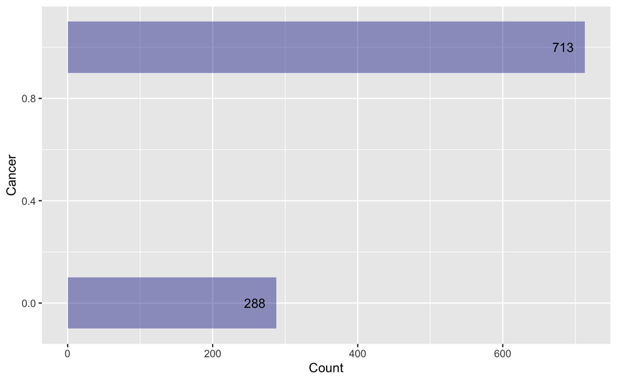

```r
ggplot(df, aes(y = POP)) +
  geom_bar(width=.2, fill="darkblue", alpha=0.4) +
  xlab("Count") +
  ylab("Cancer") +
  geom_text(stat='count', aes(label=..count..), hjust=1.5, vjust=.5)
```

## 6. Feature Selection

### 6.1 Correlation matrix

```r
df.cor <- df %>%
      mutate(POP = ifelse(POP == 1, 0, 1))
str(df.cor)
```

```
'data.frame':   1001 obs. of  4 variables:
 $ POP    : num  0 1 0 0 1 0 0 1 0 0 ...
 $ Dnu    : num  4.45 6.94 2.65 4.24 10.45 ...
 $ numax  : num  43.1 74.1 21.6 32.1 120.4 ...
 $ epsilon: num  0.985 0.15 0.855 0.84 0.275 0.945 0.985 0.215 0.885 0.855 ...
```

### 6.2 One-hot encoding

```r
# df.cor = df
# df.cor$diagnosis_result <- factor(df.cor$diagnosis_result,
#                  levels=c('M', 'B'),
#                  labels=c(0, 1))
# df.cor$diagnosis_result = as.numeric(df.cor$diagnosis_result)
```

### 6.3 Correlation heatmap

```r
cormat <- round(cor(select(df.cor, c("POP", "Dnu", "numax", "epsilon"))), 3)
# Merge data
melted_cormat = melt(cormat)
```

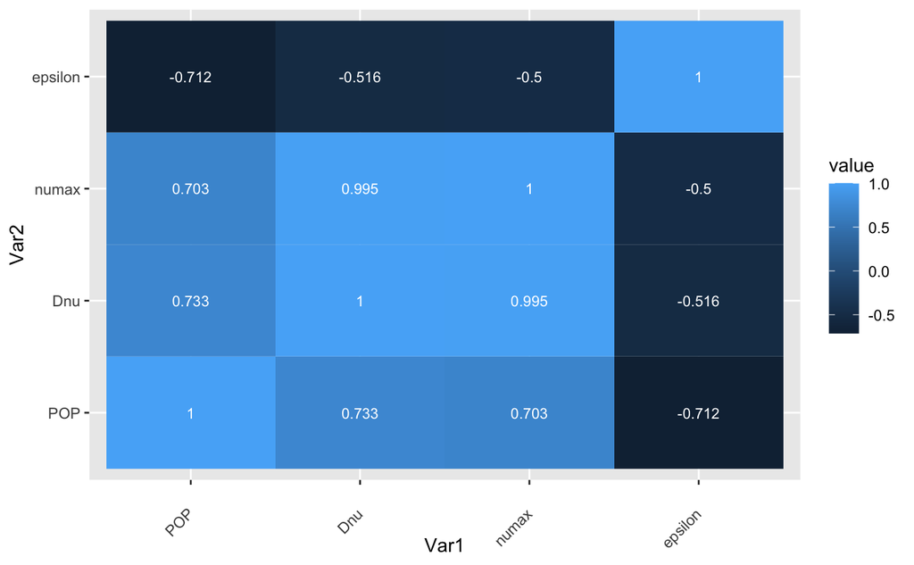

```r
ggplot(data=melted_cormat, aes(x=Var1, y=Var2, fill=value)) +
  geom_tile() +
  theme(axis.text.x=element_text(angle=45, hjust=1, vjust=.5)) +
  geom_text(aes(Var2, Var1, label = value),color='white', size=3)
```

What a perfect dataset! Strong correlations between independent variables and the dependent variable.

### 6.4 Feature selection

```r
# df.cor = subset(df.cor, select = -c(fractal_dimension, texture, perimeter) )
# str(df.cor)
```

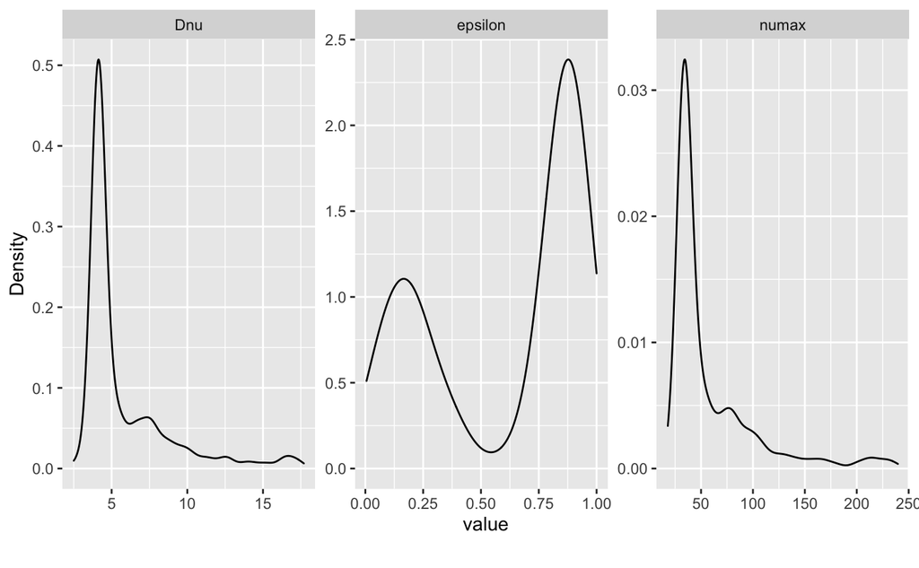

```r
plot_density(df)
```

Clearly, all the dimensions do not follow the Gaussian distribution.

## 7. Data Normalization

```r
# Normalization
min_max_norm <- function(x) {
      (x - min(x)) / (max(x) - min(x))
}
# df.norm = df.cor
df.norm <- as.data.frame(lapply(df, min_max_norm))
```

#### Notice that we use Min-Max normalization instead of Standardization for data rescaling for two reasons.First, we want to bound the data between 0 and 1. Also, all data doesn’t follow Gaussian Distribution. Their distributions are unkown to us.

```r
sum(is.na(df))
```

```
[1] 0
```

```r
summary(df.norm)
```

```
      POP              Dnu             numax            epsilon
 Min.   :0.0000   Min.   :0.0000   Min.   :0.00000   Min.   :0.0000
 1st Qu.:0.0000   1st Qu.:0.1035   1st Qu.:0.06742   1st Qu.:0.2161
 Median :1.0000   Median :0.1190   Median :0.09164   Median :0.8141
 Mean   :0.7123   Mean   :0.2155   Mean   :0.18253   Mean   :0.6088
 3rd Qu.:1.0000   3rd Qu.:0.2684   3rd Qu.:0.23531   3rd Qu.:0.8894
 Max.   :1.0000   Max.   :1.0000   Max.   :1.00000   Max.   :1.0000
```

## 8. Dataset Partitioning

We use 80% of the data set for training, and the rest for testing.

```r
# 80% of the sample size
smp_size <- floor(0.80 * nrow(df))
set.seed(123)
train_ind <- sample(seq_len(nrow(df.norm)), size = smp_size)
train <- df.norm[train_ind, ]
test <- df.norm[-train_ind, ]
```

### 8.1 Check data distribution

```r
prop.table(table(df.norm$POP))
```

```
        0         1
0.2877123 0.7122877
```

```r
prop.table(table(train$POP))
```

```
      0       1
0.27375 0.72625
```

```r
prop.table(table(test$POP))
```

```
        0         1
0.3432836 0.6567164
```

## 9. SVC model

### 9.1 SVM model with the RBF kernel

```r
# Define SVM model with the rbf kernel.
svm_rbf <- svm(POP~., data = train)
summary(svm_rbf)
```

```
Call:
svm(formula = POP ~ ., data = train)


Parameters:
   SVM-Type:  eps-regression
 SVM-Kernel:  radial
       cost:  1
      gamma:  0.3333333
    epsilon:  0.1


Number of Support Vectors:  157
```

```r
# Training process and confusion statistics
pred_prob_train = predict (svm_rbf, train)
pred_class_train = ifelse(pred_prob_train > 0.5, 1, 0)
confusionMatrix(table(Predicted = pred_class_train, Actual = train$POP))
```

```
Confusion Matrix and Statistics

         Actual
Predicted   0   1
        0 206  29
        1  13 552

               Accuracy : 0.9475
                 95% CI : (0.9297, 0.9619)
    No Information Rate : 0.7262
    P-Value [Acc > NIR] : < 2e-16

                  Kappa : 0.8709

 Mcnemar's Test P-Value : 0.02064

            Sensitivity : 0.9406
            Specificity : 0.9501
         Pos Pred Value : 0.8766
         Neg Pred Value : 0.9770
             Prevalence : 0.2737
         Detection Rate : 0.2575
   Detection Prevalence : 0.2938
      Balanced Accuracy : 0.9454

       'Positive' Class : 0
```

```r
# Testing process and confusion statistics
pred_prob_test = predict (svm_rbf, test)
pred_class_test = ifelse(pred_prob_test > 0.5, 1, 0)
cm = table(Predicted = pred_class_test, Actual = test$POP)
confusionMatrix(cm)
```

```
Confusion Matrix and Statistics

         Actual
Predicted   0   1
        0  69  10
        1   0 122

               Accuracy : 0.9502
                 95% CI : (0.9104, 0.9759)
    No Information Rate : 0.6567
    P-Value [Acc > NIR] : < 2.2e-16

                  Kappa : 0.8933

 Mcnemar's Test P-Value : 0.004427

            Sensitivity : 1.0000
            Specificity : 0.9242
         Pos Pred Value : 0.8734
         Neg Pred Value : 1.0000
             Prevalence : 0.3433
         Detection Rate : 0.3433
   Detection Prevalence : 0.3930
      Balanced Accuracy : 0.9621

       'Positive' Class : 0
```

```r
# Testing accuracy
accuracy = sum(diag(cm))/sum(cm)*100
accuracy
```

```
[1] 95.02488
```

### 9.2 SVM model with the linear kernel

```r
# Define SVM model with the linear kernel.
svm_linear <- svm(POP~., data = train, kernel = "linear")
summary(svm_linear)
```

```
Call:
svm(formula = POP ~ ., data = train, kernel = "linear")


Parameters:
   SVM-Type:  eps-regression
 SVM-Kernel:  linear
       cost:  1
      gamma:  0.3333333
    epsilon:  0.1


Number of Support Vectors:  503
```

```r
# Training process and confusion statistics
pred_prob_train = predict (svm_linear, train)
pred_class_train = ifelse(pred_prob_train > 0.5, 1, 0)
confusionMatrix(table(Predicted = pred_class_train, Actual = train$POP))
```

```
Confusion Matrix and Statistics

         Actual
Predicted   0   1
        0 215  71
        1   4 510

               Accuracy : 0.9062
                 95% CI : (0.8839, 0.9255)
    No Information Rate : 0.7262
    P-Value [Acc > NIR] : < 2.2e-16

                  Kappa : 0.7847

 Mcnemar's Test P-Value : 2.517e-14

            Sensitivity : 0.9817
            Specificity : 0.8778
         Pos Pred Value : 0.7517
         Neg Pred Value : 0.9922
             Prevalence : 0.2737
         Detection Rate : 0.2687
   Detection Prevalence : 0.3575
      Balanced Accuracy : 0.9298

       'Positive' Class : 0
```

```r
# Testing process and confusion statistics
pred_prob_test = predict (svm_linear, test)
pred_class_test = ifelse(pred_prob_test > 0.5, 1, 0)
cm = table(Predicted = pred_class_test, Actual = test$POP)
confusionMatrix(cm)
```

```
Confusion Matrix and Statistics

         Actual
Predicted   0   1
        0  69  20
        1   0 112

               Accuracy : 0.9005
                 95% CI : (0.8505, 0.9382)
    No Information Rate : 0.6567
    P-Value [Acc > NIR] : 1.030e-15

                  Kappa : 0.7936

 Mcnemar's Test P-Value : 2.152e-05

            Sensitivity : 1.0000
            Specificity : 0.8485
         Pos Pred Value : 0.7753
         Neg Pred Value : 1.0000
             Prevalence : 0.3433
         Detection Rate : 0.3433
   Detection Prevalence : 0.4428
      Balanced Accuracy : 0.9242

       'Positive' Class : 0
```

```r
# Testing accuracy
accuracy = sum(diag(cm))/sum(cm)*100
accuracy
```

```
[1] 90.04975
```

### 9.3 SVM model with the sigmoid kernel

```r
# Define SVM model with the sigmoid kernel.
svm_sigmoid <- svm(POP~., data = train, kernel = "sigmoid")
summary(svm_sigmoid)
```

```
Call:
svm(formula = POP ~ ., data = train, kernel = "sigmoid")


Parameters:
   SVM-Type:  eps-regression
 SVM-Kernel:  sigmoid
       cost:  1
      gamma:  0.3333333
     coef.0:  0
    epsilon:  0.1


Number of Support Vectors:  767
```

```r
# Training process and confusion statistics
pred_prob_train = predict (svm_sigmoid, train)
pred_class_train = ifelse(pred_prob_train > 0.5, 1, 0)
confusionMatrix(table(Predicted = pred_class_train, Actual = train$POP))
```

```
Confusion Matrix and Statistics

         Actual
Predicted   0   1
        0 127 147
        1  92 434

               Accuracy : 0.7012
                 95% CI : (0.6682, 0.7328)
    No Information Rate : 0.7262
    P-Value [Acc > NIR] : 0.9469812

                  Kappa : 0.3032

 Mcnemar's Test P-Value : 0.0004777

            Sensitivity : 0.5799
            Specificity : 0.7470
         Pos Pred Value : 0.4635
         Neg Pred Value : 0.8251
             Prevalence : 0.2737
         Detection Rate : 0.1588
   Detection Prevalence : 0.3425
      Balanced Accuracy : 0.6634

       'Positive' Class : 0
```

```r
# Testing process and confusion statistics
pred_prob_test = predict (svm_sigmoid, test)
pred_class_test = ifelse(pred_prob_test > 0.5, 1, 0)
cm = table(Predicted = pred_class_test, Actual = test$POP)
confusionMatrix(cm)
```

```
Confusion Matrix and Statistics

         Actual
Predicted  0  1
        0 43 43
        1 26 89

               Accuracy : 0.6567
                 95% CI : (0.5866, 0.7221)
    No Information Rate : 0.6567
    P-Value [Acc > NIR] : 0.53267

                  Kappa : 0.2809

 Mcnemar's Test P-Value : 0.05408

            Sensitivity : 0.6232
            Specificity : 0.6742
         Pos Pred Value : 0.5000
         Neg Pred Value : 0.7739
             Prevalence : 0.3433
         Detection Rate : 0.2139
   Detection Prevalence : 0.4279
      Balanced Accuracy : 0.6487

       'Positive' Class : 0
```

```r
# Testing accuracy
accuracy = sum(diag(cm))/sum(cm)*100
accuracy
```

```
[1] 65.67164
```

### 9.4 SVM model with the polynomial kernel

```r
# Define SVM model with the polynomial kernel.
svm_polynomial <- svm(POP~., data = train, kernel = "polynomial")
summary(svm_polynomial)
```

```
Call:
svm(formula = POP ~ ., data = train, kernel = "polynomial")


Parameters:
   SVM-Type:  eps-regression
 SVM-Kernel:  polynomial
       cost:  1
     degree:  3
      gamma:  0.3333333
     coef.0:  0
    epsilon:  0.1


Number of Support Vectors:  568
```

```r
# Training process and confusion statistics
pred_prob_train = predict (svm_polynomial, train)
pred_class_train = ifelse(pred_prob_train > 0.5, 1, 0)
confusionMatrix(table(Predicted = pred_class_train, Actual = train$POP))
```

```
Confusion Matrix and Statistics

         Actual
Predicted   0   1
        0 189  21
        1  30 560

               Accuracy : 0.9362
                 95% CI : (0.917, 0.9522)
    No Information Rate : 0.7262
    P-Value [Acc > NIR] : <2e-16

                  Kappa : 0.8376

 Mcnemar's Test P-Value : 0.2626

            Sensitivity : 0.8630
            Specificity : 0.9639
         Pos Pred Value : 0.9000
         Neg Pred Value : 0.9492
             Prevalence : 0.2737
         Detection Rate : 0.2362
   Detection Prevalence : 0.2625
      Balanced Accuracy : 0.9134

       'Positive' Class : 0
```

```r
# Testing process and confusion statistics
pred_prob_test = predict (svm_polynomial, test)
pred_class_test = ifelse(pred_prob_test > 0.5, 1, 0)
cm = table(Predicted = pred_class_test, Actual = test$POP)
confusionMatrix(cm)
```

```
Confusion Matrix and Statistics

         Actual
Predicted   0   1
        0  61   7
        1   8 125

               Accuracy : 0.9254
                 95% CI : (0.8799, 0.9576)
    No Information Rate : 0.6567
    P-Value [Acc > NIR] : <2e-16

                  Kappa : 0.8339

 Mcnemar's Test P-Value : 1

            Sensitivity : 0.8841
            Specificity : 0.9470
         Pos Pred Value : 0.8971
         Neg Pred Value : 0.9398
             Prevalence : 0.3433
         Detection Rate : 0.3035
   Detection Prevalence : 0.3383
      Balanced Accuracy : 0.9155

       'Positive' Class : 0
```

```r
# Testing accuracy
accuracy = sum(diag(cm))/sum(cm)*100
accuracy
```

```
[1] 92.53731
```

## 10. Model Tuning

### 10.1 Hyper-parameters tuning

1. ‘C’: controls the strength of regularization, thus affecting generalization.
- A large ‘C’ value results in a small decision boundary. Therefore, it reduces the generalization ability.
- A small ‘C’ values leads to a large decision boundary. But it will classify few instances to a wrong category.
2. ‘Gamma’: controls the influence of each instance (only applied to rbf and sigmoid kernels).
- A high ‘Gamma’ value allows the model to consider only the instances close to the decision boundary.
- A low ‘Gamma’ value allows the model to equally take all instances into consideration when calculating decision boundary.

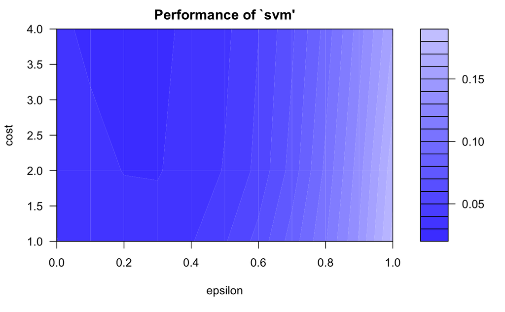

```r
# Set random seed
set.seed(123)

# Tuning function tunes the hyper-parameters of the model using grid search method.
# Here, we tune the SVM model with a rbf kernel since it has the best performance.
tuned_model = tune(svm, POP~., data=train,
     ranges = list(epsilon = seq (0, 1, 0.1), cost = 2^(0:2)))
plot (tuned_model)
```

```r
# summary (tuned_model)
tuned_model$best.parameters
```

|  | epsilon | cost |
| --- | --- | --- |
| 24 | 0.1 | 4 |

```r
opt_model = tuned_model$best.model
summary(opt_model)
```

```
Call:
best.tune(method = svm, train.x = POP ~ ., data = train, ranges = list(epsilon = seq(0,
    1, 0.1), cost = 2^(0:2)))


Parameters:
   SVM-Type:  eps-regression
 SVM-Kernel:  radial
       cost:  4
      gamma:  0.3333333
    epsilon:  0.1


Number of Support Vectors:  182
```

### 10.2 Further tuning

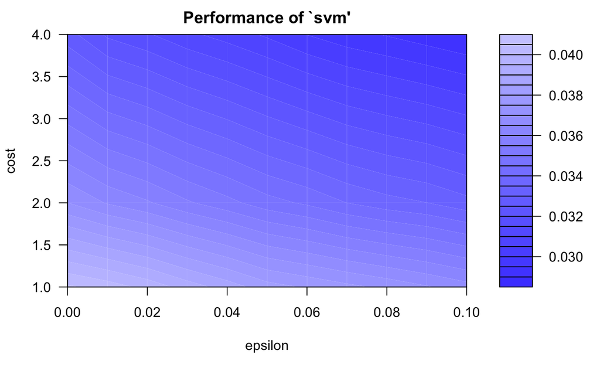

```r
# Tuning function tunes the hyper-parameters of the model using grid search method.
tuned_model = tune(svm, POP~., data=train,
     ranges = list(epsilon = seq (0, 0.1, 0.01), cost = 2^(0:2)))
plot (tuned_model)
```

```r
# summary (tuned_model)
tuned_model$best.parameters
```

|  | epsilon | cost |
| --- | --- | --- |
| 33 | 0.1 | 4 |

```r
opt_model = tuned_model$best.model
summary(opt_model)
```

```
Call:
best.tune(method = svm, train.x = POP ~ ., data = train, ranges = list(epsilon = seq(0,
    0.1, 0.01), cost = 2^(0:2)))


Parameters:
   SVM-Type:  eps-regression
 SVM-Kernel:  radial
       cost:  4
      gamma:  0.3333333
    epsilon:  0.1


Number of Support Vectors:  182
```

### 10.3 Test SVM with the best hyper-parameters combination

```r
# Building the best model with selected hyper-parameters
svm_best <- svm (POP~., data = train, epsilon = 0.1, cost = 4)

# Training process and confusion statistics
pred_prob_train = predict (svm_best, train)
pred_class_train = ifelse(pred_prob_train > 0.5, 1, 0)
confusionMatrix(table(Predicted = pred_class_train, Actual = train$POP))
```

```
Confusion Matrix and Statistics

         Actual
Predicted   0   1
        0 203   9
        1  16 572

               Accuracy : 0.9688
                 95% CI : (0.9542, 0.9797)
    No Information Rate : 0.7262
    P-Value [Acc > NIR] : <2e-16

                  Kappa : 0.9206

 Mcnemar's Test P-Value : 0.2301

            Sensitivity : 0.9269
            Specificity : 0.9845
         Pos Pred Value : 0.9575
         Neg Pred Value : 0.9728
             Prevalence : 0.2737
         Detection Rate : 0.2537
   Detection Prevalence : 0.2650
      Balanced Accuracy : 0.9557

       'Positive' Class : 0
```

```r
# Testing process and confusion statistics
pred_prob_test = predict (svm_best, test)
pred_class_test = ifelse(pred_prob_test > 0.5, 1, 0)
cm = table(Predicted = pred_class_test, Actual = test$POP)
confusionMatrix(cm)
```

```
Confusion Matrix and Statistics

         Actual
Predicted   0   1
        0  69   7
        1   0 125

               Accuracy : 0.9652
                 95% CI : (0.9296, 0.9859)
    No Information Rate : 0.6567
    P-Value [Acc > NIR] : < 2e-16

                  Kappa : 0.9246

 Mcnemar's Test P-Value : 0.02334

            Sensitivity : 1.0000
            Specificity : 0.9470
         Pos Pred Value : 0.9079
         Neg Pred Value : 1.0000
             Prevalence : 0.3433
         Detection Rate : 0.3433
   Detection Prevalence : 0.3781
      Balanced Accuracy : 0.9735

       'Positive' Class : 0
```

```r
# Testing accuracy
accuracy = sum(diag(cm))/sum(cm)*100
accuracy
```

```
[1] 96.51741
```

## 11. AUC & ROC Analysis

```r
# To draw ROC we need to predict the prob values.
pred = prediction(pred_prob_test, test$POP)
perf = performance(pred, "tpr", "fpr")
pred
```

```
A prediction instance
  with 201 data points
```

```r
perf
```

```
A performance instance
  'False positive rate' vs. 'True positive rate' (alpha: 'Cutoff')
  with 202 data points
```

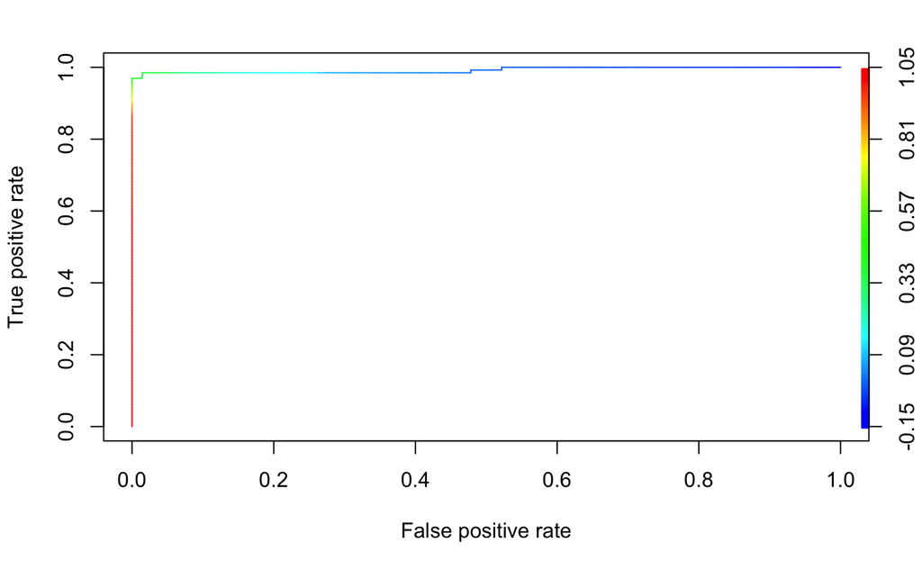

```r
plot(perf, colorize = T)
```

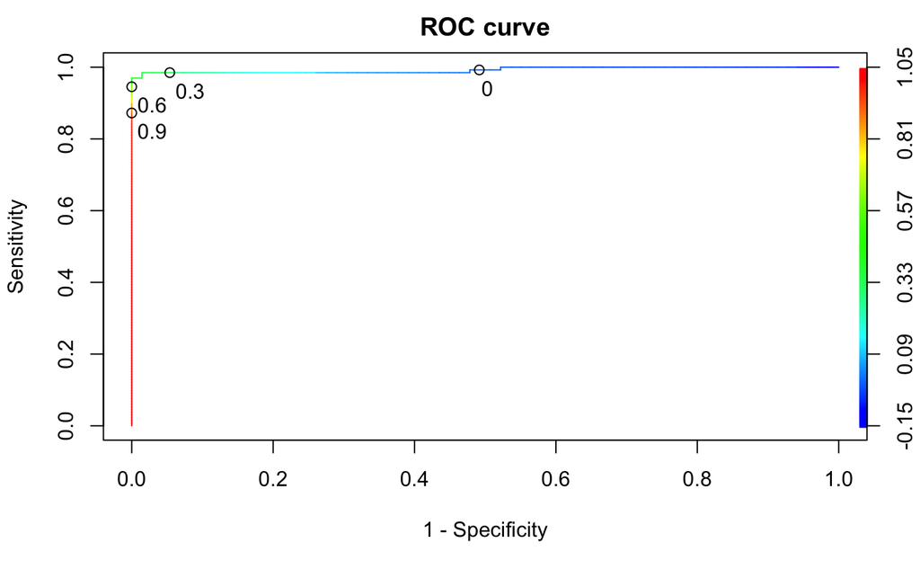

```r
plot(perf, colorize=T,
     main = "ROC curve",
     ylab = "Sensitivity",
     xlab = "1 - Specificity",
     print.cutoffs.at=seq(0,1,0.3),
     text.adj= c(-0.2,1.7))
```

```r
# Area Under Curve
auc <- as.numeric(performance(pred, "auc")@y.values)
auc <-  round(auc, 3)
auc
```

```
[1] 0.992
```

```r
cat("Last Block!")
```

```
Last Block!
```